# HW 16 - NMDS

Sean Fahey

2023-04-17

# In Class Work

**NMDS**

*similar to PCA*

- get distance matrix
- use different distance/dissimilarity methods
- algo. generates new ordination (order for values)
- compares order to initial distance matrix. Calculate goodness of fit (called stress)
- finds minimum stress value. Plots how samples are arranged in 2-D.

**Bray Curtis**

- doesn’t vary when units change
- unaffected by addition or removal of species not found in a pair of communities. (if 2 sites share a set of species, they should be similar)
- unaffected by adding new communities/sites
- Can show difference in abundance, ie. if one site is far more abundance than another even though the two sites share the same number of species.
- value of 1 = sites have nothing in common
- value of 0 = sites are identical

```r
veg = read.csv("bryceveg.txt", header=TRUE, sep=' ', row.names=1)
sites = read.csv("brycesite.txt", header=TRUE, sep=' ', row.names=1)
```

### meta-MDS

slightly fancier than normal NMDS, does refitting for us automatically

PCA gives us one principal componenet per column in dataset, MDS gives us k components (depending on what k we specify)

```r
# k=2 means do this in 2 dimensions
bc.nmds = metaMDS(comm = veg, distance = "bray", k = 2, trace = 0)

bc.nmds
```

```
##
## Call:
## metaMDS(comm = veg, distance = "bray", k = 2, trace = 0)
##
## global Multidimensional Scaling using monoMDS
##
## Data:     veg
## Distance: bray
##
## Dimensions: 2
## Stress:     0.1405379
## Stress type 1, weak ties
## Best solution was repeated 1 time in 20 tries
## The best solution was from try 10 (random start)
## Scaling: centring, PC rotation, halfchange scaling
## Species: expanded scores based on 'veg'
```

stress value is ~0.14. General rule of thumb is that below 0.2, below 0.1 is very good, 0 is best.

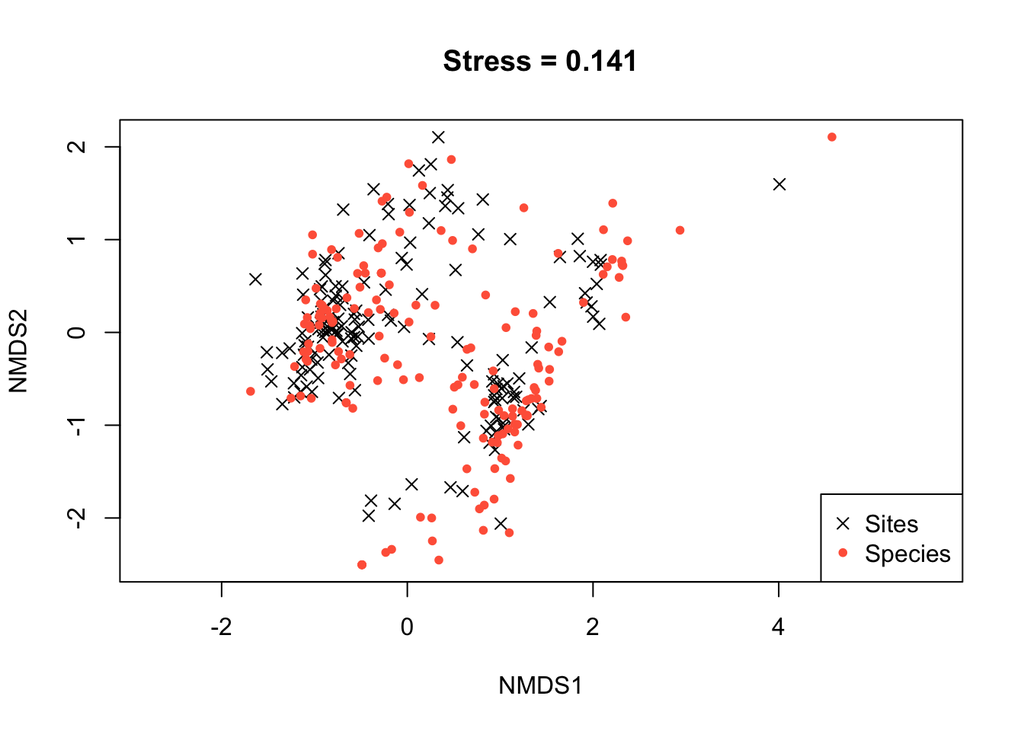

```r
pl = ordiplot(
  bc.nmds,
  type='none',
  main=paste0( # plot title
    'Stress = ',
    round(bc.nmds$stress,dig=3)
    )
  )

points(pl, what='sites', col="black", pch=4) # add points for the sites

points(pl, what='species', col='tomato', pch=20) # add points for the species

legend( # add legend at bottom
  'bottomright',
  legend=c('Sites', 'Species'),
  col=c('black', 'tomato'),
  pch=c(4,20)
  )
```

### Stress

Stress is the goodness of fit measurement. A stress of 0.2 means roughly 80% of the variation in the original distance matrix can be explained by the 2 MDS components.

### Ordination Plots

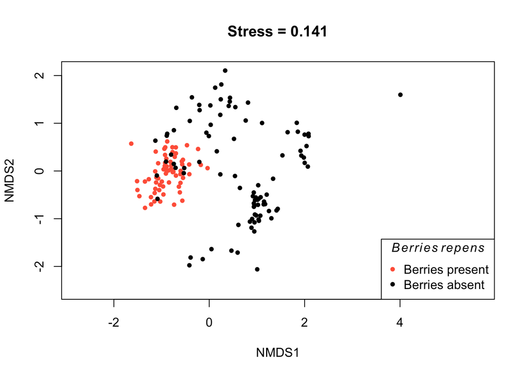

```r
pl = ordiplot(
  bc.nmds,
  type='none',
  main=paste0( # plot title
    'Stress = ',
    round(bc.nmds$stress,dig=3)
    )
  )

# add points for sites where berries present
points(pl, veg$berrep>0, what='sites', col="tomato", pch=20)

# add points for sites where berries absent
points(pl, veg$berrep == 0, what='sites', col='black', pch=20)

legend( # add legend at bottom
  'bottomright',
  legend=c('Berries present', 'Berries absent'),
  col=c('tomato', 'black'),
  pch=c(20,20),
  title=expression(italic(Berries ~ repens))
  )
```

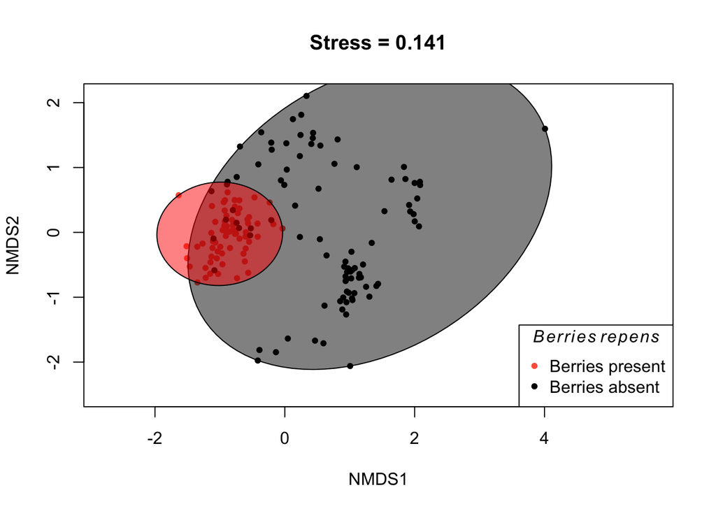

```r
pl = ordiplot(
  bc.nmds,
  type='none',
  main=paste0( # plot title
    'Stress = ',
    round(bc.nmds$stress,dig=3)
    )
  )

# add points for sites where berries present
points(pl, veg$berrep>0, what='sites', col="tomato", pch=20)

# add points for sites where berries absent
points(pl, veg$berrep == 0, what='sites', col='black', pch=20)

legend( # add legend at bottom
  'bottomright',
  legend=c('Berries present', 'Berries absent'),
  col=c('tomato', 'black'),
  pch=c(20,20),
  title=expression(italic(Berries ~ repens))
  )

# add an outline where the groups are found.
ordiellipse(
  bc.nmds,
  kind='ehull', # how to include points, this means all (?)
  draw="polygon",
  groups=veg$berrep>0,
  col=c('black', 'red'),
  label=F
  )
```

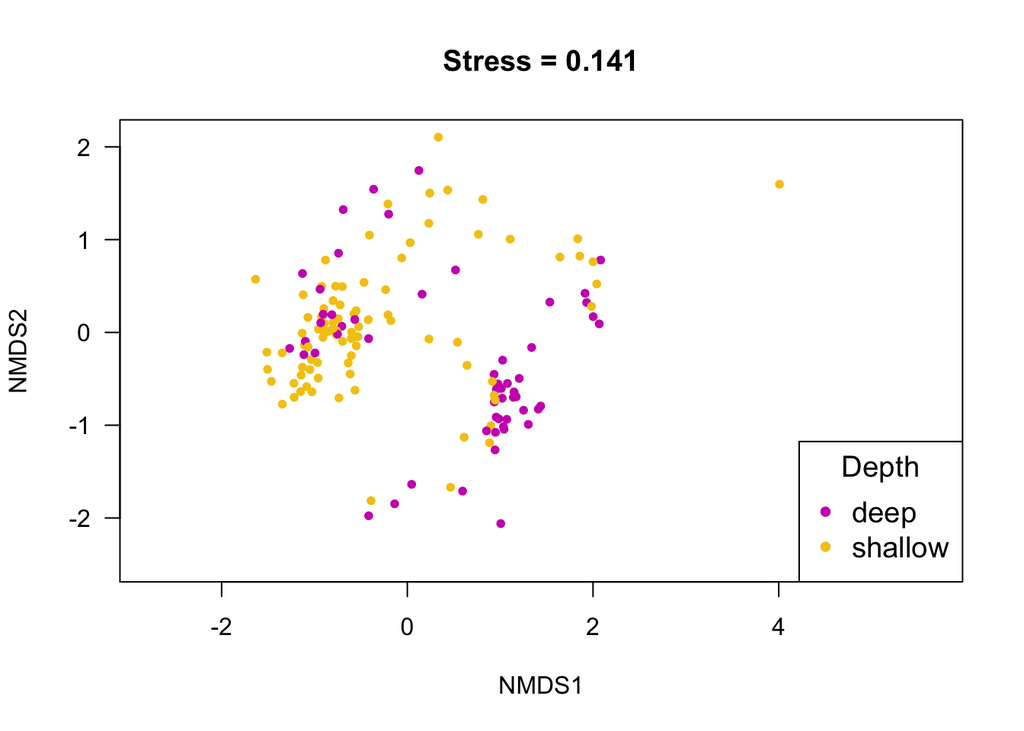

```r
# make the depth column a factor
sites$depth = as.factor(sites$depth)

pl = ordiplot(
  bc.nmds,
  type='none',
  main=paste0( # plot title
    'Stress = ',
    round(bc.nmds$stress,dig=3)
    ),
  las = 1
  )

# add points colored by sites column
# this gives me color number 5 and 6, change the addition to change the color
# pair
points(pl, what='sites', col=as.numeric(sites$depth)+5, pch=20)

legend( # add legend at bottom
  'bottomright',
  legend=levels(sites$depth),
  col=6:7, # make the colors match the points
  pch=20,
  cex=1.2,
  title="Depth"
  )
```

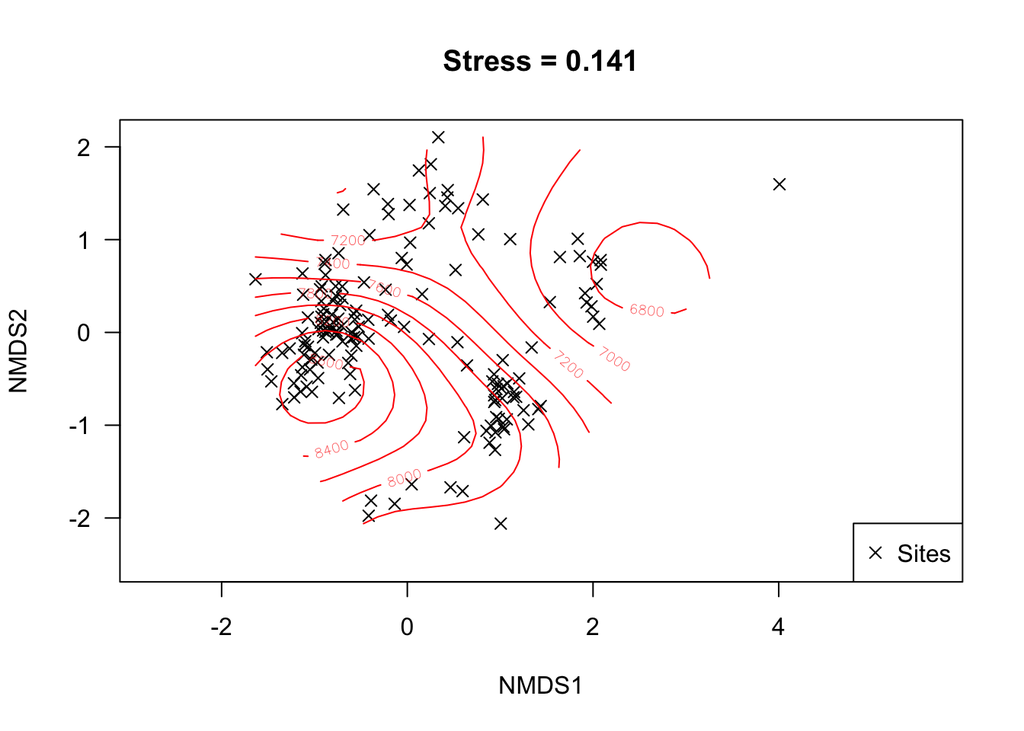

```
##
## Family: gaussian
## Link function: identity
##
## Formula:
## y ~ s(x1, x2, k = 10, bs = "tp", fx = FALSE)
##
## Estimated degrees of freedom:
## 6.81  total = 7.81
##
## REML score: 1121.07
```

```r
pl = ordiplot(
  bc.nmds,
  type='none',
  main=paste0( # plot title
    'Stress = ',
    round(bc.nmds$stress,dig=3)
    ),
  las = 1
  )

# add points colored by sites column
# this gives me color number 5 and 6, change the addition to change the color
# pair
points(pl, what='sites', col='black', pch=4)

legend( # add legend at bottom
  'bottomright',
  legend="Sites",
  col='black', # make the colors match the points
  pch=4,
  )

# add contour markers for elevation of site
ordisurf(bc.nmds, sites$elev, main='', add=TRUE)
```

```r
ef2 = envfit(bc.nmds, sites[,c('elev', 'av', 'slope')])
ef2
```

```
##
## ***VECTORS
##
##          NMDS1    NMDS2     r2 Pr(>r)
## elev  -0.72984 -0.68362 0.6386  0.001 ***
## av    -0.63772 -0.77027 0.0554  0.013 *
## slope  0.06153  0.99811 0.0937  0.001 ***
## ---
## Signif. codes:  0 '***' 0.001 '**' 0.01 '*' 0.05 '.' 0.1 ' ' 1
## Permutation: free
## Number of permutations: 999
```

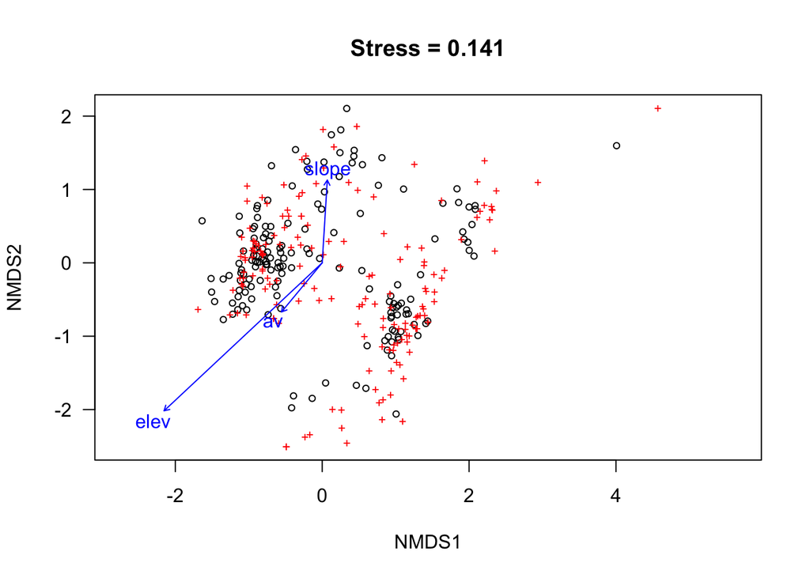

```r
ordiplot(
  bc.nmds,
  main=paste0(
    "Stress = ",
    round(bc.nmds$stress, dig=3)),
  las=1
  )

plot(ef2)
```

There’s no units on an NMDS plot, because we converted to a rank-order. Typically there’s not even ticks on an axis when publishing the values.

### Standardization and transformation

- metaNMDS applies a default transformation
- some common transformations:
  1. sq root transformation
  2. 4th root (double sq root)
  3. log-transform
  4. Wisconsin

# Homework

*instructions*

- Run a NMDS on the bird data (macnally_full2.csv, leave out columns 1&2, SITE + HABITAT), using Bray-Curtis as the distance metric with the vegan metaMDS function
- Generate a NMDS ordination plot showing the sites only (no species arrows), and draw ellipsoid hulls around each of the 6 habitat types to show how habitat maps onto the ordination.
  - Color the site points by HABITAT type (column 2 of data frame)
  - Use the ordiellipse() function, and the groups argument should be defined using the HABITAT data in column 2 of the data frame
  - Include a legend in the plot to show which point color maps to which habitat type

### NMDS

```r
bird = read.csv("macnally_full2.csv", header=TRUE, sep=',', row.names=1)
bird$HABITAT = as.factor(bird$HABITAT)
```

NMDS summary

```r
bird.nmds = metaMDS(comm = bird[c(-1,-2)], distance = "bray", k = 2, trace = 0)

bird.nmds
```

```
##
## Call:
## metaMDS(comm = bird[c(-1, -2)], distance = "bray", k = 2, trace = 0)
##
## global Multidimensional Scaling using monoMDS
##
## Data:     wisconsin(sqrt(bird[c(-1, -2)]))
## Distance: bray
##
## Dimensions: 2
## Stress:     0.1175554
## Stress type 1, weak ties
## Best solution was repeated 5 times in 20 tries
## The best solution was from try 8 (random start)
## Scaling: centring, PC rotation, halfchange scaling
## Species: expanded scores based on 'wisconsin(sqrt(bird[c(-1, -2)]))'
```

ordination plot with just sites

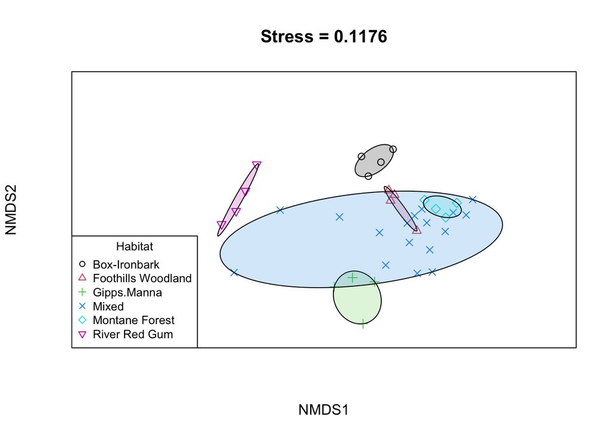

```r
bird.plot = ordiplot(
  bird.nmds,
  type='none',
  main=paste0( # plot title
    'Stress = ',
    round(bird.nmds$stress,dig=4) # add stress label to title
    ),
  xaxt='none', # remove tick marks from NMDS plots
  yaxt='none'
  )

# add data points
points(
  bird.plot,
  what='sites',
  col=as.numeric(bird$HABITAT), # color by habitat
  pch=as.numeric(bird$HABITAT) # shape by habitat
  )

legend( # add legend at bottom left
  'bottomleft',
  legend=levels(bird$HABITAT),
  col=1:6, # make the colors match the points
  pch=1:6, # make the shapes match
  cex=0.8,
  title="Habitat"
  )

ordiellipse(
  bird.nmds,
  kind='ehull', # how to include points, this means all (?)
  draw="polygon",
  col=1:6,
  alpha=0.2,
  groups=bird$HABITAT,
  label=F
  )
```

**Question:** Based on your plot, describe which (if any) of the habitats differ in community composition

**Answer:** Two of the habitats are clearly different from the others in the NMDS ordination plot: *Box-Ironbank* and *Red River Gum*. These points do not overlap at all with any other habitat. The remaining habitats all overlap the mixed group.